# Practical Machine Learning Course Project1

Stanley Kan Chuen LAM

February 7, 2018

## 1. Synposis

This report describes the analysis of the machine learning models used to predict the manner in which participants did the exercise, identified by the “classe” variable in the training set. Data from accelerometers on the belt, forearm, arm, and dumbell of 6 participants is used. Both supervised and unsupervised trainings models (basic ones) are studied.

Background : Using devices such as Jawbone Up, Nike FuelBand, and Fitbit it is now possible to collect a large amount of data about personal activity relatively inexpensively. These type of devices are part of the quantified self movement – a group of enthusiasts who take measurements about themselves regularly to improve their health, to find patterns in their behavior, or because they are tech geeks. One thing that people regularly do is quantify how much of a particular activity they do, but they rarely quantify how well they do it. In this project, your goal will be to use data from accelerometers on the belt, forearm, arm, and dumbell of 6 participants. They were asked to perform barbell lifts correctly and incorrectly in 5 different ways. More information is available from the website here: http://web.archive.org/web/20161224072740/http:/groupware.les.inf.puc-rio.br/har (see the section on the Weight Lifting Exercise Dataset).

The training data for this project are available here:

https://d396qusza40orc.cloudfront.net/predmachlearn/pml-training.csv

The test data are available here:

https://d396qusza40orc.cloudfront.net/predmachlearn/pml-testing.csv

## 2. Load necessary libraries

```r
library(caret)
library(randomForest)
library(parallel)
library(doParallel)
```

## 3. Import Data

```r
pml.training <- read.csv("./pml-training.csv", na.strings=c("", "NA"))
pml.testing <- read.csv("./pml-testing.csv", na.strings=c("", "NA"))

dim(pml.training)
```

```
## [1] 19622   160
```

```r
str(pml.training)
```

```
## 'data.frame':    19622 obs. of  160 variables:
##  $ X                       : int  1 2 3 4 5 6 7 8 9 10 ...
##  $ user_name               : Factor w/ 6 levels "adelmo","carlitos",..: 2 2 2 2 2 2 2 2 2 2 ...
##  $ raw_timestamp_part_1    : int  1323084231 1323084231 1323084231 1323084232 1323084232 1323084232 1323084232 1323084232 1323084232 1323084232 ...
##  $ raw_timestamp_part_2    : int  788290 808298 820366 120339 196328 304277 368296 440390 484323 484434 ...
##  $ cvtd_timestamp          : Factor w/ 20 levels "02/12/2011 13:32",..: 9 9 9 9 9 9 9 9 9 9 ...
##  $ new_window              : Factor w/ 2 levels "no","yes": 1 1 1 1 1 1 1 1 1 1 ...
##  $ num_window              : int  11 11 11 12 12 12 12 12 12 12 ...
##  $ roll_belt               : num  1.41 1.41 1.42 1.48 1.48 1.45 1.42 1.42 1.43 1.45 ...
##  $ pitch_belt              : num  8.07 8.07 8.07 8.05 8.07 8.06 8.09 8.13 8.16 8.17 ...
##  $ yaw_belt                : num  -94.4 -94.4 -94.4 -94.4 -94.4 -94.4 -94.4 -94.4 -94.4 -94.4 ...
##  $ total_accel_belt        : int  3 3 3 3 3 3 3 3 3 3 ...
##  $ kurtosis_roll_belt      : Factor w/ 396 levels "-0.016850","-0.021024",..: NA NA NA NA NA NA NA NA NA NA ...
##  $ kurtosis_picth_belt     : Factor w/ 316 levels "-0.021887","-0.060755",..: NA NA NA NA NA NA NA NA NA NA ...
##  $ kurtosis_yaw_belt       : Factor w/ 1 level "#DIV/0!": NA NA NA NA NA NA NA NA NA NA ...
```

[output cut: 86 more lines]

## 4. Data Cleansing & Data Splitting

Remove variables which are more than 97% null or NA.

```r
NAvar <- names(which((colSums(is.na(pml.training))/nrow(pml.training))>0.97))

pml.training <- pml.training[!(names(pml.training) %in% NAvar)]
pml.testing  <- pml.testing[!(names(pml.testing) %in% NAvar)]
```

Remove indices, user_names, timestamps & windows related variables

```r
pml.training <- pml.training[,-c(1:7)]
pml.testing  <- pml.testing[,-c(1:7)]
```

Data Splitting

```r
set.seed(1724) # randomly selected seed
inTrain  <- createDataPartition(pml.training$classe, p=0.75, list=FALSE)
training <- pml.training[inTrain,]
testing  <- pml.training[-inTrain,]
```

## 5. Enabling Parallel Processing

According to the mentor’s recommendation in the forum, let’s enable Parallel Processing.

```r
cluster <- makeCluster(detectCores() - 1) # convention to leave 1 core for OS
registerDoParallel(cluster)
```

## 6. Modelling

6.1 LDA

```r
modelLDA   <- train(classe~., method="lda", data=training,
                    trControl = trainControl(allowParallel = TRUE))
ptrainLDA  <- predict(modelLDA, training)
ptestLDA   <- predict(modelLDA, testing)
cftrainLDA <- confusionMatrix(training$classe, ptrainLDA)
cftestLDA  <- confusionMatrix(testing$classe, ptestLDA)
cftrainLDA
```

```
## Confusion Matrix and Statistics
##
##           Reference
## Prediction    A    B    C    D    E
##          A 3433   90  335  313   14
##          B  440 1813  364  103  128
##          C  245  245 1715  301   61
##          D  148  108  271 1787   98
##          E   97  426  259  253 1671
##
## Overall Statistics
##
##                Accuracy : 0.7079
##                  95% CI : (0.7005, 0.7152)
##     No Information Rate : 0.2964
##     P-Value [Acc > NIR] : < 2.2e-16
##
##                   Kappa : 0.6304
##  Mcnemar's Test P-Value : < 2.2e-16
##
## Statistics by Class:
##
##                      Class: A Class: B Class: C Class: D Class: E
## Sensitivity            0.7868   0.6760   0.5825   0.6482   0.8474
## Specificity            0.9274   0.9140   0.9276   0.9477   0.9188
## Pos Pred Value         0.8203   0.6366   0.6681   0.7409   0.6175
## Neg Pred Value         0.9117   0.9268   0.8989   0.9212   0.9749
## Prevalence             0.2964   0.1822   0.2000   0.1873   0.1340
## Detection Rate         0.2333   0.1232   0.1165   0.1214   0.1135
## Detection Prevalence   0.2843   0.1935   0.1744   0.1639   0.1839
## Balanced Accuracy      0.8571   0.7950   0.7551   0.7980   0.8831
```

```r
cftestLDA
```

```
## Confusion Matrix and Statistics
##
##           Reference
## Prediction    A    B    C    D    E
##          A 1133   36  119  100    7
##          B  148  611  105   35   50
##          C   82   85  565  104   19
##          D   48   26  119  572   39
##          E   35  174   85   79  528
##
## Overall Statistics
##
##                Accuracy : 0.6951
##                  95% CI : (0.682, 0.708)
##     No Information Rate : 0.2949
##     P-Value [Acc > NIR] : < 2.2e-16
##
##                   Kappa : 0.6142
##  Mcnemar's Test P-Value : < 2.2e-16
##
## Statistics by Class:
##
##                      Class: A Class: B Class: C Class: D Class: E
## Sensitivity            0.7835   0.6556   0.5690   0.6427   0.8212
## Specificity            0.9242   0.9149   0.9259   0.9422   0.9125
## Pos Pred Value         0.8122   0.6438   0.6608   0.7114   0.5860
## Neg Pred Value         0.9108   0.9188   0.8943   0.9224   0.9713
## Prevalence             0.2949   0.1900   0.2025   0.1815   0.1311
## Detection Rate         0.2310   0.1246   0.1152   0.1166   0.1077
## Detection Prevalence   0.2845   0.1935   0.1743   0.1639   0.1837
## Balanced Accuracy      0.8539   0.7852   0.7474   0.7924   0.8668
```

6.2 GBM

```r
modelGBM   <- train(classe~., method="gbm", data=training,
                    trControl = trainControl(allowParallel = TRUE))
ptrainGBM  <- predict(modelGBM, training)
ptestGBM   <- predict(modelGBM, testing)
cftrainGBM <- confusionMatrix(training$classe, ptrainGBM)
cftestGBM  <- confusionMatrix(testing$classe, ptestGBM)
cftrainGBM
```

```
## Confusion Matrix and Statistics
##
##           Reference
## Prediction    A    B    C    D    E
##          A 4146   30    5    2    2
##          B   63 2724   60    1    0
##          C    0   55 2486   23    3
##          D    1    2   61 2336   12
##          E    3   18   18   23 2644
##
## Overall Statistics
##
##                Accuracy : 0.974
##                  95% CI : (0.9713, 0.9766)
##     No Information Rate : 0.2862
##     P-Value [Acc > NIR] : < 2.2e-16
##
##                   Kappa : 0.9672
##  Mcnemar's Test P-Value : 1.565e-10
##
## Statistics by Class:
##
##                      Class: A Class: B Class: C Class: D Class: E
## Sensitivity            0.9841   0.9629   0.9452   0.9795   0.9936
## Specificity            0.9963   0.9896   0.9933   0.9938   0.9949
## Pos Pred Value         0.9907   0.9565   0.9684   0.9685   0.9771
## Neg Pred Value         0.9936   0.9912   0.9881   0.9960   0.9986
## Prevalence             0.2862   0.1922   0.1787   0.1620   0.1808
## Detection Rate         0.2817   0.1851   0.1689   0.1587   0.1796
## Detection Prevalence   0.2843   0.1935   0.1744   0.1639   0.1839
## Balanced Accuracy      0.9902   0.9762   0.9693   0.9866   0.9942
```

```r
cftestGBM
```

```
## Confusion Matrix and Statistics
##
##           Reference
## Prediction    A    B    C    D    E
##          A 1373   17    4    0    1
##          B   36  891   22    0    0
##          C    0   23  825    7    0
##          D    0    1   42  754    7
##          E    1    8    4   12  876
##
## Overall Statistics
##
##                Accuracy : 0.9623
##                  95% CI : (0.9566, 0.9674)
##     No Information Rate : 0.2875
##     P-Value [Acc > NIR] : < 2.2e-16
##
##                   Kappa : 0.9523
##  Mcnemar's Test P-Value : NA
##
## Statistics by Class:
##
##                      Class: A Class: B Class: C Class: D Class: E
## Sensitivity            0.9738   0.9479   0.9197   0.9754   0.9910
## Specificity            0.9937   0.9854   0.9925   0.9879   0.9938
## Pos Pred Value         0.9842   0.9389   0.9649   0.9378   0.9723
## Neg Pred Value         0.9895   0.9876   0.9822   0.9954   0.9980
## Prevalence             0.2875   0.1917   0.1829   0.1576   0.1803
## Detection Rate         0.2800   0.1817   0.1682   0.1538   0.1786
## Detection Prevalence   0.2845   0.1935   0.1743   0.1639   0.1837
## Balanced Accuracy      0.9837   0.9666   0.9561   0.9817   0.9924
```

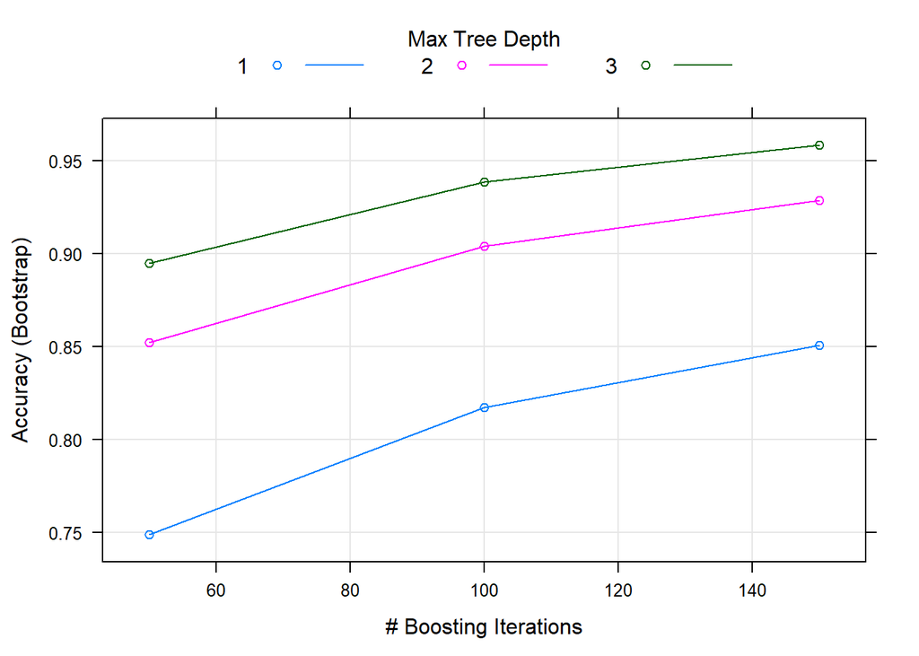

```r
plot(modelGBM)
```

6.3 Random Forest ntree=5

Note that, instead of using the caret::train(method=“rf”) function, the randomforest::randomforest function(few mins) is used since it runs by far faster than the caret::train(over an hour, even with parallel processing).

```r
modelRF5   <- randomForest(classe~., data=training, ntree=5)
ptrainRF5  <- predict(modelRF5, training)
ptestRF5   <- predict(modelRF5, testing)
cftrainRF5 <- confusionMatrix(training$classe, ptrainRF5)
cftestRF5  <- confusionMatrix(testing$classe, ptestRF5)
cftrainRF5
```

```
## Confusion Matrix and Statistics
##
##           Reference
## Prediction    A    B    C    D    E
##          A 4183    0    1    1    0
##          B    1 2844    3    0    0
##          C    0    4 2562    1    0
##          D    1    1    5 2405    0
##          E    0    1    0    3 2702
##
## Overall Statistics
##
##                Accuracy : 0.9985
##                  95% CI : (0.9977, 0.9991)
##     No Information Rate : 0.2843
##     P-Value [Acc > NIR] : < 2.2e-16
##
##                   Kappa : 0.9981
##  Mcnemar's Test P-Value : NA
##
## Statistics by Class:
##
##                      Class: A Class: B Class: C Class: D Class: E
## Sensitivity            0.9995   0.9979   0.9965   0.9979   1.0000
## Specificity            0.9998   0.9997   0.9996   0.9994   0.9997
## Pos Pred Value         0.9995   0.9986   0.9981   0.9971   0.9985
## Neg Pred Value         0.9998   0.9995   0.9993   0.9996   1.0000
## Prevalence             0.2843   0.1936   0.1747   0.1637   0.1836
## Detection Rate         0.2842   0.1932   0.1741   0.1634   0.1836
## Detection Prevalence   0.2843   0.1935   0.1744   0.1639   0.1839
## Balanced Accuracy      0.9997   0.9988   0.9980   0.9987   0.9998
```

```r
cftestRF5
```

```
## Confusion Matrix and Statistics
##
##           Reference
## Prediction    A    B    C    D    E
##          A 1383    3    3    2    4
##          B    8  925   12    1    3
##          C    0    9  842    4    0
##          D    3    3   19  775    4
##          E    1    3    1    5  891
##
## Overall Statistics
##
##                Accuracy : 0.9821
##                  95% CI : (0.9779, 0.9856)
##     No Information Rate : 0.2845
##     P-Value [Acc > NIR] : < 2e-16
##
##                   Kappa : 0.9773
##  Mcnemar's Test P-Value : 0.03332
##
## Statistics by Class:
##
##                      Class: A Class: B Class: C Class: D Class: E
## Sensitivity            0.9914   0.9809   0.9601   0.9848   0.9878
## Specificity            0.9966   0.9939   0.9968   0.9930   0.9975
## Pos Pred Value         0.9914   0.9747   0.9848   0.9639   0.9889
## Neg Pred Value         0.9966   0.9954   0.9914   0.9971   0.9973
## Prevalence             0.2845   0.1923   0.1788   0.1605   0.1839
## Detection Rate         0.2820   0.1886   0.1717   0.1580   0.1817
## Detection Prevalence   0.2845   0.1935   0.1743   0.1639   0.1837
## Balanced Accuracy      0.9940   0.9874   0.9784   0.9889   0.9927
```

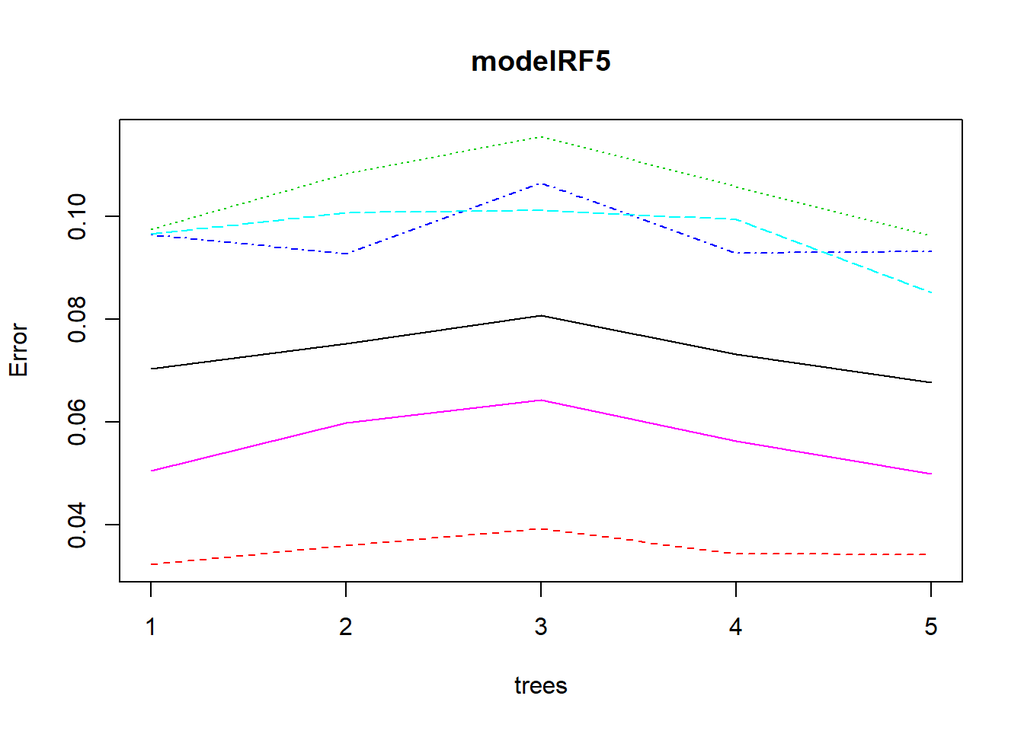

```r
plot(modelRF5)
```

6.4 Random Forest, ntree=50

```r
modelRF50   <- randomForest(classe~., data=training, ntree=50)
ptrainRF50  <- predict(modelRF50, training)
ptestRF50   <- predict(modelRF50, testing)
cftrainRF50 <- confusionMatrix(training$classe, ptrainRF50)
cftestRF50  <- confusionMatrix(testing$classe, ptestRF50)
cftrainRF50
```

```
## Confusion Matrix and Statistics
##
##           Reference
## Prediction    A    B    C    D    E
##          A 4185    0    0    0    0
##          B    0 2848    0    0    0
##          C    0    0 2567    0    0
##          D    0    0    0 2412    0
##          E    0    0    0    0 2706
##
## Overall Statistics
##
##                Accuracy : 1
##                  95% CI : (0.9997, 1)
##     No Information Rate : 0.2843
##     P-Value [Acc > NIR] : < 2.2e-16
##
##                   Kappa : 1
##  Mcnemar's Test P-Value : NA
##
## Statistics by Class:
##
##                      Class: A Class: B Class: C Class: D Class: E
## Sensitivity            1.0000   1.0000   1.0000   1.0000   1.0000
## Specificity            1.0000   1.0000   1.0000   1.0000   1.0000
## Pos Pred Value         1.0000   1.0000   1.0000   1.0000   1.0000
## Neg Pred Value         1.0000   1.0000   1.0000   1.0000   1.0000
## Prevalence             0.2843   0.1935   0.1744   0.1639   0.1839
## Detection Rate         0.2843   0.1935   0.1744   0.1639   0.1839
## Detection Prevalence   0.2843   0.1935   0.1744   0.1639   0.1839
## Balanced Accuracy      1.0000   1.0000   1.0000   1.0000   1.0000
```

```r
cftestRF50
```

```
## Confusion Matrix and Statistics
##
##           Reference
## Prediction    A    B    C    D    E
##          A 1394    0    1    0    0
##          B    5  941    3    0    0
##          C    0    3  852    0    0
##          D    0    0   12  791    1
##          E    0    0    1    1  899
##
## Overall Statistics
##
##                Accuracy : 0.9945
##                  95% CI : (0.992, 0.9964)
##     No Information Rate : 0.2853
##     P-Value [Acc > NIR] : < 2.2e-16
##
##                   Kappa : 0.993
##  Mcnemar's Test P-Value : NA
##
## Statistics by Class:
##
##                      Class: A Class: B Class: C Class: D Class: E
## Sensitivity            0.9964   0.9968   0.9804   0.9987   0.9989
## Specificity            0.9997   0.9980   0.9993   0.9968   0.9995
## Pos Pred Value         0.9993   0.9916   0.9965   0.9838   0.9978
## Neg Pred Value         0.9986   0.9992   0.9958   0.9998   0.9998
## Prevalence             0.2853   0.1925   0.1772   0.1615   0.1835
## Detection Rate         0.2843   0.1919   0.1737   0.1613   0.1833
## Detection Prevalence   0.2845   0.1935   0.1743   0.1639   0.1837
## Balanced Accuracy      0.9981   0.9974   0.9898   0.9978   0.9992
```

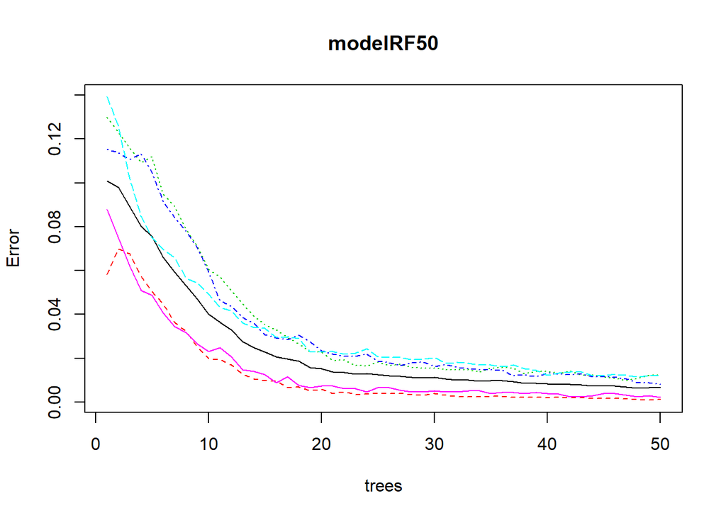

```r
plot(modelRF50)
```

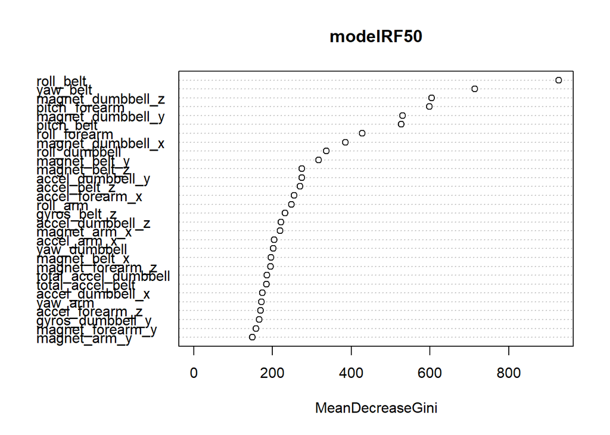

```r
varImpPlot(modelRF50)
```

Observation : It can be seen that beyond ntree=40, the change in Error become insignificant. Hence, select ntree=50.

6.5 Random Forest, top 10 important variables, ntree=50

```r
vImp <- varImp(modelRF50)
trainingIMP10 <- training[order(vImp$Overall, decreasing = T)[1:10]]
trainingIMP10 <- data.frame(trainingIMP10, classe=training$classe)
modelRFIMP10   <- randomForest(classe~., data=trainingIMP10, ntree=50)
ptrainRFIMP10  <- predict(modelRFIMP10, trainingIMP10)
ptestRFIMP10   <- predict(modelRFIMP10, testing)
cftrainRFIMP10 <- confusionMatrix(training$classe,
                                  ptrainRFIMP10)
cftestRFIMP10  <- confusionMatrix(testing$classe,
                                  ptestRFIMP10)
cftrainRFIMP10
```

```
## Confusion Matrix and Statistics
##
##           Reference
## Prediction    A    B    C    D    E
##          A 4184    1    0    0    0
##          B    0 2848    0    0    0
##          C    0    0 2567    0    0
##          D    0    0    0 2412    0
##          E    0    0    0    0 2706
##
## Overall Statistics
##
##                Accuracy : 0.9999
##                  95% CI : (0.9996, 1)
##     No Information Rate : 0.2843
##     P-Value [Acc > NIR] : < 2.2e-16
##
##                   Kappa : 0.9999
##  Mcnemar's Test P-Value : NA
##
## Statistics by Class:
##
##                      Class: A Class: B Class: C Class: D Class: E
## Sensitivity            1.0000   0.9996   1.0000   1.0000   1.0000
## Specificity            0.9999   1.0000   1.0000   1.0000   1.0000
## Pos Pred Value         0.9998   1.0000   1.0000   1.0000   1.0000
## Neg Pred Value         1.0000   0.9999   1.0000   1.0000   1.0000
## Prevalence             0.2843   0.1936   0.1744   0.1639   0.1839
## Detection Rate         0.2843   0.1935   0.1744   0.1639   0.1839
## Detection Prevalence   0.2843   0.1935   0.1744   0.1639   0.1839
## Balanced Accuracy      1.0000   0.9998   1.0000   1.0000   1.0000
```

```r
cftestRFIMP10
```

```
## Confusion Matrix and Statistics
##
##           Reference
## Prediction    A    B    C    D    E
##          A 1380    2    9    2    2
##          B   15  913   16    5    0
##          C    0    4  850    1    0
##          D    0    0   11  792    1
##          E    0    4    0    1  896
##
## Overall Statistics
##
##                Accuracy : 0.9851
##                  95% CI : (0.9813, 0.9883)
##     No Information Rate : 0.2845
##     P-Value [Acc > NIR] : < 2.2e-16
##
##                   Kappa : 0.9812
##  Mcnemar's Test P-Value : NA
##
## Statistics by Class:
##
##                      Class: A Class: B Class: C Class: D Class: E
## Sensitivity            0.9892   0.9892   0.9594   0.9888   0.9967
## Specificity            0.9957   0.9910   0.9988   0.9971   0.9988
## Pos Pred Value         0.9892   0.9621   0.9942   0.9851   0.9945
## Neg Pred Value         0.9957   0.9975   0.9911   0.9978   0.9993
## Prevalence             0.2845   0.1882   0.1807   0.1633   0.1833
## Detection Rate         0.2814   0.1862   0.1733   0.1615   0.1827
## Detection Prevalence   0.2845   0.1935   0.1743   0.1639   0.1837
## Balanced Accuracy      0.9925   0.9901   0.9791   0.9929   0.9977
```

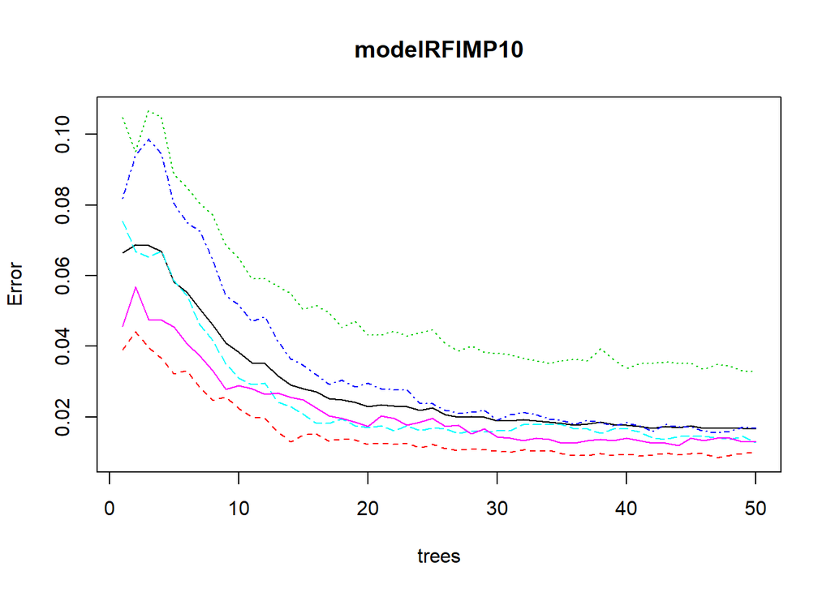

```r
plot(modelRFIMP10)
```

Close parallel processing

```r
stopCluster(cluster)
registerDoSEQ()
```

## 7. Summary of model accuracies & Conclusion

```r
v1 <- c(cftrainLDA$overall[1],
        cftrainGBM$overall[1],
        cftrainRF5$overall[1],
        cftrainRF50$overall[1],
        cftrainRFIMP10$overall[1])

v2 <- c(cftestLDA$overall[1],
        cftestGBM$overall[1],
        cftestRF5$overall[1],
        cftestRF50$overall[1],
        cftestRFIMP10$overall[1])

modeloutofsamplerror <- data.frame(Training = round(1-v1, 3),
                       Testing = round(1-v2, 3))
rownames(modeloutofsamplerror) <- c("LDA", "GBM", "RF5", "RF50", "RFIMP10")

message("Out of Sample Errors")
```

```
## Out of Sample Errors
```

```r
modeloutofsamplerror
```

```
##         Training Testing
## LDA        0.292   0.305
## GBM        0.026   0.038
## RF5        0.001   0.018
## RF50       0.000   0.006
## RFIMP10    0.000   0.015
```

Conclusion : It can be seen that Random Forest with ntree=50, RF50, has the lowest Out-of-Sample Error on the testing set. Let’s use this model to do the 20 samples test set prediction for the quiz.

## 8. Predictions on given 20 samples test set

Let’s summaries the prediction results of all models in a table

```r
predall <- data.frame(predict(modelLDA, pml.testing),
                      predict(modelGBM, pml.testing),
                      predict(modelRF5, pml.testing),
                      predict(modelRF50, pml.testing),
                      predict(modelRFIMP10, pml.testing))
colnames(predall) <- c("LDA", "GBM", "RF5", "RF50", "RFIMP10")
predall
```

```
##    LDA GBM RF5 RF50 RFIMP10
## 1    B   B   B    B       B
## 2    A   A   A    A       A
## 3    B   B   B    B       B
## 4    C   A   A    A       A
## 5    C   A   A    A       A
## 6    E   E   E    E       E
## 7    D   D   D    D       D
## 8    D   B   B    B       B
## 9    A   A   A    A       A
## 10   A   A   A    A       A
## 11   D   B   B    B       B
## 12   A   C   C    C       C
## 13   B   B   B    B       B
## 14   A   A   A    A       A
## 15   E   E   E    E       E
## 16   A   E   E    E       E
## 17   A   A   A    A       A
## 18   B   B   B    B       B
## 19   B   B   B    B       B
## 20   B   B   B    B       B
```

## 9. Experiment on unsupervised training : Kmeans clustering

Let’s do an experiment using kmeans, with 5 centers, as 5 different “classe” is a known fact.

```r
set.seed(8237) # randomly selected seed
kMeans1 <- kmeans(subset(training,select=-c(classe)),centers=5)
table(kMeans1$cluster,training$classe)
```

```
##
##        A    B    C    D    E
##   1  462  559  226  136  313
##   2  473  336  351  346  325
##   3  268  380  159  428  518
##   4 2271  549  982  476  464
##   5  711 1024  849 1026 1086
```

```r
kMeans1 <- kmeans(subset(training,select=-c(classe)),centers=5)
table(kMeans1$cluster,training$classe)
```

```
##
##        A    B    C    D    E
##   1  532  467  678  816  610
##   2  520  771  315  425  707
##   3 2230  515  913  459  415
##   4  473  354  355  362  334
##   5  430  741  306  350  640
```

```r
kMeans1 <- kmeans(subset(training,select=-c(classe)),centers=5)
table(kMeans1$cluster,training$classe)
```

```
##
##        A    B    C    D    E
##   1  718  942  764 1064 1007
##   2  551  799  325  458  751
##   3  473  354  357  362  335
##   4  386  213  172  204  157
##   5 2057  540  949  324  456
```

From the results tables of the 3 runs, we cannot tell which number(1-5) could match distinctively to individual classe(A-E). The classe matching results are not good and hence stop further investigation for the time being.